# Deliverable 1

### 12. Payment_type

This variable is categorical but it is expressed as numerical, so we need to factor it in order to be able to work with it.

```r
df$Payment_type<-factor(df$Payment_type,labels=c("Credit card","Cash","No charge","Dispute"))
summary(df$Payment_type)
```

```
## Credit card        Cash   No charge     Dispute
##        2455        2506          21          18
```

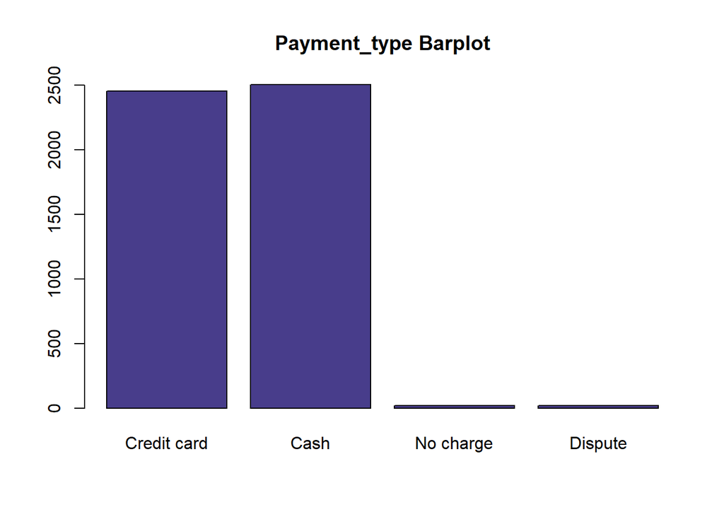

```r
barplot(summary(df$Payment_type),main="Payment_type Barplot",col = "DarkSlateBlue")
```

As we can see, there are few values with “No charge” or “Dispute” category, so we decided to categorize it into a new category (“No paid”).

```r
levels(df$Payment_type) <- c("Credit card","Cash","No paid","No paid")
summary(df$Payment_type)
```

```
## Credit card        Cash     No paid
##        2455        2506          39
```

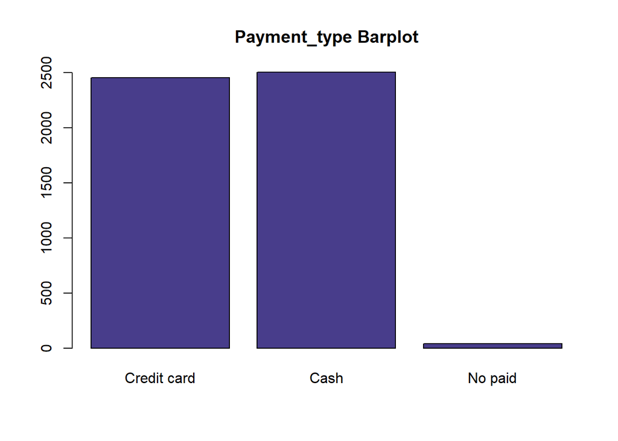

```r
barplot(summary(df$Payment_type),main="Payment_type Barplot",col = "DarkSlateBlue")
```

### 21. Trip_type

This variable is categorical but it is expressed as numerical, so we need to factor it in order to be able to work with it.

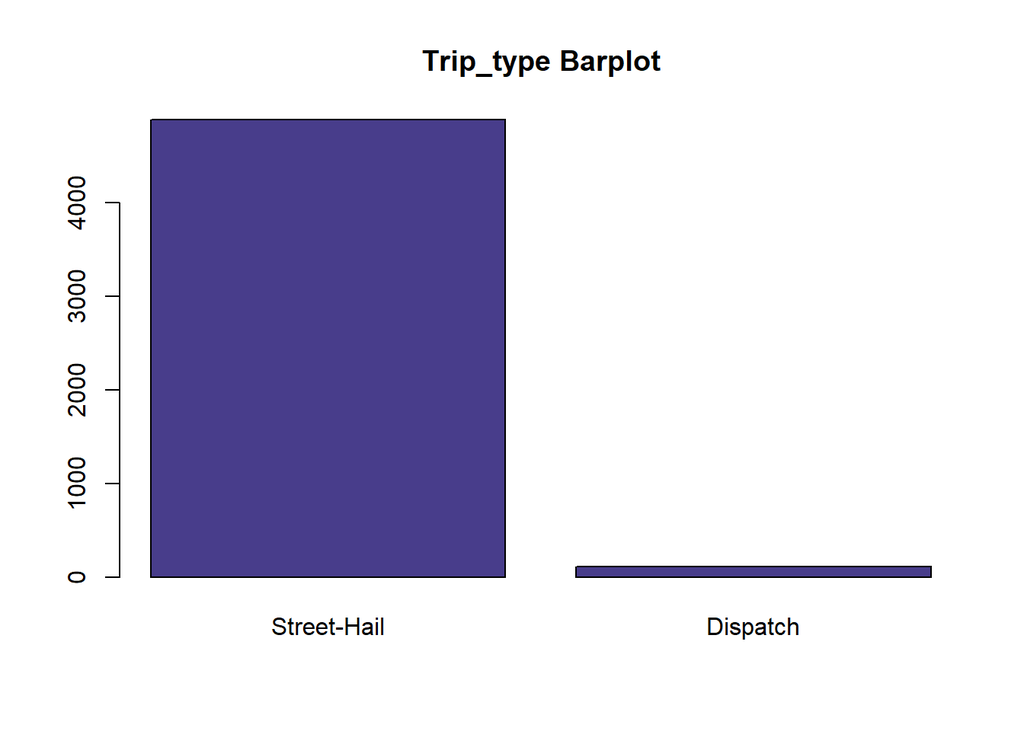

```r
df$Trip_type<-factor(df$Trip_type,labels=c("Street-Hail","Dispatch"))
barplot(summary(df$Trip_type),main="Trip_type Barplot",col = "DarkSlateBlue")
```

```r
summary(df$Trip_type)
```

```
## Street-Hail    Dispatch
##        4885         115
```

## Quantitative Variables

**Description**: Original numeric variables corresponding to real quantitative concepts are kept as numeric but additional factors should also be created as a discretization of each numeric variable.

We only keep the hours (variables 2 and 3) to be able to work with time slots in the future.

Create new variables derived from the original ones, as effective speed, travel time, hour of request, period of request, effective trip distance (in km)

### New variables: Trip Length in km, Travel time un min and Effective speed

#### Trip length in km

```r
df$tlenkm<-df$Trip_distance*1.609344 # Miles to km
```

#### Travel time in min

```r
df$traveltime<-(as.numeric(as.POSIXct(df$Lpep_dropoff_datetime)) - as.numeric(as.POSIXct(df$lpep_pickup_datetime)))/60
```

#### Effective speed in km/h

```r
df$espeed<-(df$tlenkm/(df$traveltime))*60
```

#### Missing data

```r
sel<-which(is.na(df$espeed<=0)) #;length(sel)
#imis[sel]<-imis[sel]+1
#jmis[26]<-length(sel)
```

#### Error detection

```r
summary(df$espeed)
```

```
##    Min. 1st Qu.  Median    Mean 3rd Qu.    Max.    NA's
##    0.00   14.60   18.58   23.07   23.70 3881.74       2
```

```r
sel<-which((df$espeed<=0)|(df$espeed=="Inf"))
ierrs[sel]<-ierrs[sel]+1
jerrs[26]<-length(sel)
# sel
```

```r
df[sel,"espeed"]<-NA
```

#### Check outliers

```r
# summary(df$espeed)
calcQ(df$espeed)
```

```
## $souti
##   1st Qu.
## -12.05656
##
## $mouti
##  1st Qu.
## 1.375907
##
## $min
##       Min.
## 0.03530885
##
## $q1
##  1st Qu.
## 14.80837
##
## $q2
##   Median
## 18.66159
##
## $q3
##  3rd Qu.
## 23.76335
##
## $max
##     Max.
## 3881.738
##
## $mouts
##  3rd Qu.
## 37.19582
##
## $souts
##  3rd Qu.
## 50.62828
```

#### Outlier detection

```r
Boxplot(df$espeed)
```

```
##  [1] 4780 3001 3066 1936  120 3578 1767 4824 2685 3009 1141  437 2859 2505 1503
## [16]   85 3096 1549 3997 2647
```

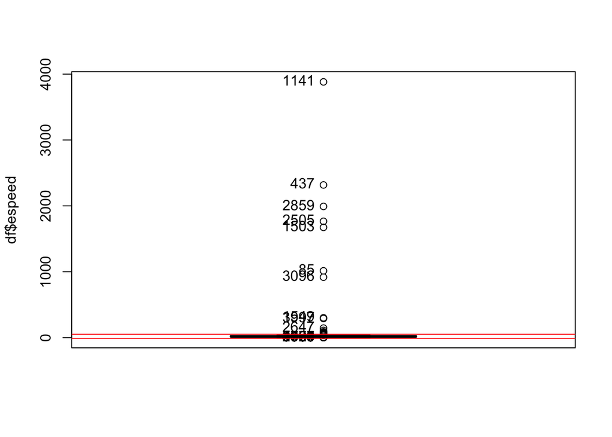

```r
var_out<-calcQ(df$espeed)
abline(h=var_out$souts,col="red")
abline(h=var_out$souti,col="red")
```

```r
llout<-which((df$espeed<=3)|(df$espeed>80))
iouts[llout]<-iouts[llout]+1
jouts[26]<-length(llout)
df[llout,"espeed"]<-NA
```

### 2. lpep_pickup_datetime

We just keep the hours

```r
df$pickup<-substr(strptime(df$lpep_pickup_datetime, "%Y-%m-%d %H:%M:%S"), 12, 13) # table(df$pickup)
```

### 3. lpep_dropoff_datetime

We just keep the hours

```r
df$dropoff<-substr(strptime(df$Lpep_dropoff_datetime, "%Y-%m-%d %H:%M:%S"), 12, 13) # table(df$pickup)
```

### 4. Passenger_count

```r
summary(df$Passenger_count)
```

```
##    Min. 1st Qu.  Median    Mean 3rd Qu.    Max.
##   0.000   1.000   1.000   1.375   1.000   6.000
```

We set the 0 as an error because it is not possible to have a trip without passengers

```r
sel<-which(df$Passenger_count == 0)
ierrs[sel]<-ierrs[sel]+1
# names(df)
jerrs[10]<-length(sel)
# sel
```

Sel contains the rownames of the individuals with “0” as value for passengers

```r
df[sel,"Passenger_count"]<-NA
```

We decided to create categorical for this variable so we categorize it for single passengers, couple and groups (3 or more)

```r
df$passenger_groups[df$Passenger_count == 1] = "Single"
df$passenger_groups[df$Passenger_count == 2] = "Couple"
df$passenger_groups[df$Passenger_count >= 3] = "Group"
df$passenger_groups <- factor(df$passenger_groups)
```

We see the barplot in order to see the distribution of passenger per trip

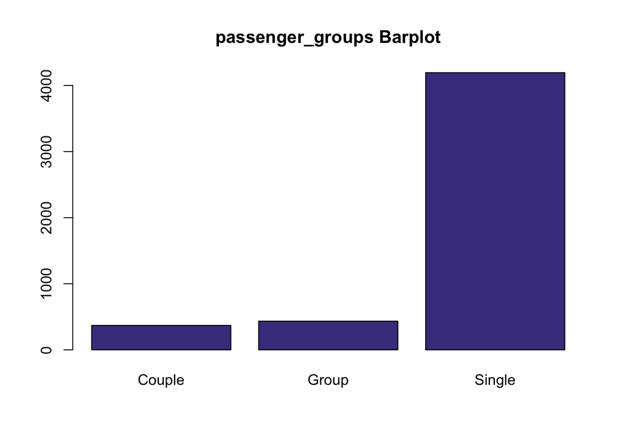

```r
barplot(table(df$passenger_groups),main="passenger_groups Barplot",col = "DarkSlateBlue")
```

### 5. Trip_distance

```r
summary(df$Trip_distance)
```

```
##    Min. 1st Qu.  Median    Mean 3rd Qu.    Max.
##   0.000   1.020   1.800   2.765   3.420  52.790
```

We see on the summary that there are not NA values, so we proceed to the outlier and error detection.

#### Outlier detection

In order to evalute or data, we decide to set the maximum trip distance to 30, so we proceed to delete the outliers.

```r
Boxplot(df$Trip_distance)
```

```
##  [1] 2680 4072 1702 2075  723 3107 2691 1105 4301 3154
```

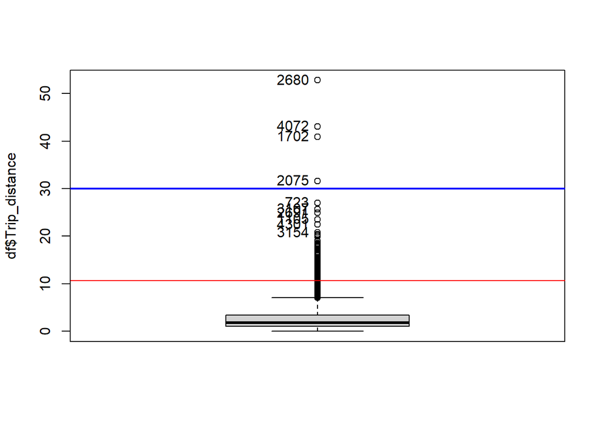

```r
var_out<-calcQ(df$Trip_distance)
abline(h=var_out$souts,col="red")
abline(h=var_out$souti,col="red")
abline(h=30,col="blue",lwd=2)
```

```r
llout<-which(df$Trip_distance>30)
iouts[llout]<-iouts[llout]+1
# names(df)
jouts[11]<-length(llout)
```

#### Error detection

We decide that an incorrect trip distance is the one with 0 miles or less. In order to be aware of this error we store it at ierrs, and jerrs. ierrs stores the number of errors in a row, and jerrs stores the total amount of errors in a variable.

```r
sel<-which(df$Trip_distance <= 0)
ierrs[sel]<-ierrs[sel]+1
# names(df)
jerrs[11]<-length(sel)
# sel
```

#### Errors and outliers

Now, we set NA values in order to remove errors and outliersfrom the dataset

```r
setNA<-which((df$Trip_distance<=0) | (df$Trip_distance > 30))
df[setNA,"Trip_distance"]<-NA
```

#### Caterogial variable for Trip_distance

We are going to set a categorical variable for the Trip_distancerange. We decided to create 3 levels: “Short_dist”, “Medium_dist” and“Long_dist”. - Short_dist <= 2.5 - Medium_dist 2.5 < Trip_distance <= 5 - Long_dist > 5

```r
df$Trip_distance_range[df$Trip_distance <= 2.5] = "Short_dist"
df$Trip_distance_range[(df$Trip_distance > 2.5) & (df$Trip_distance <= 5)] = "Medium_dist"
df$Trip_distance_range[df$Trip_distance > 5] = "Long_dist"
# summary(df$Trip_distance_range)
```

We see, though, that it is not a factor yet, so we factor it.

```r
df$Trip_distance_range <- factor(df$Trip_distance_range)
```

We see a barplot for the factor we created.

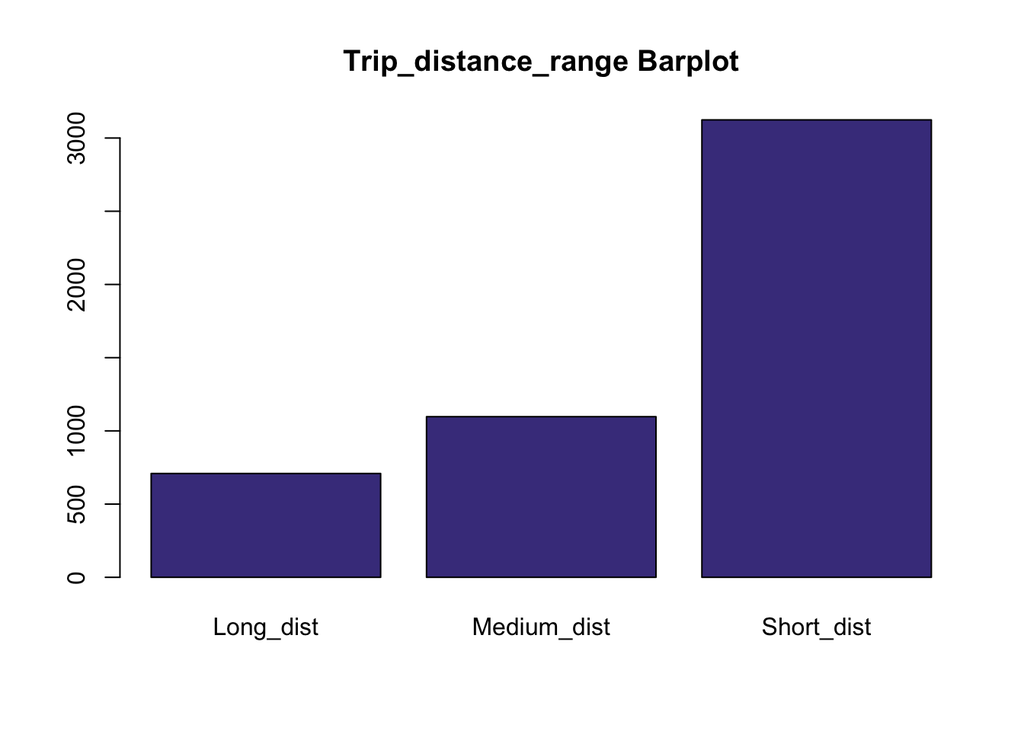

```r
barplot(table(df$Trip_distance_range),main="Trip_distance_range Barplot",col = "DarkSlateBlue")
```

### 6. Pickup_longitude

We know that New York’s longitude is -73.9385, so values that differ a lot from this value is an error or an outlier.

```r
summary(df$Pickup_longitude)
```

```
##    Min. 1st Qu.  Median    Mean 3rd Qu.    Max.
##  -75.39  -73.96  -73.95  -73.89  -73.92    0.00
```

0.00 looks to be an error Seeing the individuals with this “0” value: df[which(df[,“Pickup_longitude”]==0),] it is a quantitive variable. Non-possible values will be recoded as errors, so will be transformed to NA.

```r
sel<-which(df$Pickup_longitude == 0)
ierrs[sel]<-ierrs[sel]+1
# names(df)
jerrs[6]<-length(sel)
# sel
```

Sel contains the rownames of the individuals with “0” as value for longitude.

```r
df[sel,"Pickup_longitude"]<-NA
```

Non-possible values are replaced by NA, missing value symbol in R.

#### Which trips are not running in New-York?

Consider if, at least, one of the pick-up and drop-off points belong to New-York area. if not, this trip is an “out-of-scope” individual and has to be eliminated of the basis. Nevertheless, you have to justify thiselimination and count how many individuals were in this situation. Look at that!! possibly, starting from the outliers…“0” is missing value, outliers can help to detect trips running outside of New York…

We are deleting trips from outside New York. This means we are not using longitudes bigger than -73.80 and smaller than -74.02.

```r
llout <-which((df$Pickup_longitude < -74.02) | (df$Pickup_longitude > -73.80))
iouts[llout]<-iouts[llout]+1
# names(df)
jouts[6]<-length(llout)
```

Now that we have the outliers, we are setting them as NA

```r
df[llout,"Pickup_longitude"]<-NA
```

### 7. Pickup_latitude

We know that New York’s latitude is 40.6643, so values that differ a lot from this value is an error or an outlier.

```r
summary(df$Pickup_latitude)
```

```
##    Min. 1st Qu.  Median    Mean 3rd Qu.    Max.
##    0.00   40.70   40.75   40.72   40.80   41.04
```

0.00 looks to be an error. Seeing the individuals with this “0” value: df[which(df[,“Pickup_latitude”]==0),] it is a quantitive variable. non-possible values will be recoded as errors, so will be transformed to NA.

```r
sel<-which(df$Pickup_latitude == 0)
ierrs[sel]<-ierrs[sel]+1
# names(df)
jerrs[7]<-length(sel)
# sel
```

Sel contains the rownames of the individuals with “0” as value for longitude

```r
df[sel,"Pickup_longitude"]<-NA
```

```r
llout <-which((df$Pickup_latitude < 40.54) | (df$Pickup_latitude > 40.86))
iouts[llout]<-iouts[llout]+1
# names(df)
jouts[7]<-length(llout)
```

Now that we have the outliers, we are setting them as NA

```r
df[llout,"Pickup_latitude"]<-NA
```

### 10. Dropoff_longitude

We know that New York’s longitude is -73.9385, so values that differ a lot from this value is an error or an outlier.

```r
summary(df$Dropoff_longitude)
```

```
##    Min. 1st Qu.  Median    Mean 3rd Qu.    Max.
##  -75.31  -73.97  -73.94  -73.80  -73.91    0.00
```

0.00 looks to be an error Seeing the individuals with this “0” value: df[which(df[,“Dropoff_longitude”]==0),] it is a quantitive variable.  
Non-possible values will be recoded as errors, so will be transformed to NA.

```r
sel<-which(df$Dropoff_longitude == 0)
ierrs[sel]<-ierrs[sel]+1
# names(df)
jerrs[8]<-length(sel)
# sel
```

Sel contains the rownames of the individuals with “0” as value for longitude

```r
df[sel,"Dropoff_longitude"]<-NA
```

Non-possible values are replaced by NA, missing value symbol in R. We are deleting trips from outside New York. This means we are not using longitudes bigger than -73.80 and smaller than -74.02.

```r
llout <-which((df$Dropoff_longitude < -74.02) | (df$Dropoff_longitude > -73.80))
iouts[llout]<-iouts[llout]+1
# names(df)
jouts[8]<-length(llout)
# llout
```

Now that we have the outliers, we are setting them as NA

```r
df[llout,"Dropoff_longitude"]<-NA
```

### 11. Dropoff_latitude

We know that New York’s latitude is 40.6643, so values that differ a lot from this value is an error or an outlier.

```r
summary(df$Dropoff_latitude)
```

```
##    Min. 1st Qu.  Median    Mean 3rd Qu.    Max.
##    0.00   40.70   40.75   40.67   40.79   41.18
```

0.00 looks to be an error Seeing the individuals with this “0” value: df[which(df[,“Dropoff_latitude”]==0),] it is a quantitive variable. Non-possible values will be recoded as errors, so will be transformed to NA.

```r
sel<-which(df$Dropoff_latitude == 0)
ierrs[sel]<-ierrs[sel]+1
# names(df)
jerrs[8]<-length(sel)
# sel
```

```r
df[sel,"Dropoff_latitude"]<-NA
```

```r
llout <-which((df$Dropoff_latitude < 40.54) | (df$Dropoff_latitude > 40.86))
iouts[llout]<-iouts[llout]+1
#names(df)
jouts[9]<-length(llout)
# llout
```

Now that we have the outliers, we are setting them as NA

```r
df[llout,"Dropoff_latitude"]<-NA
```

### 13. Fare_amount

We know that the fare should be positive, as it is the price of the trip, so we’ll treat as error those values. The next we’ll do is decide the outliers.

```r
summary(df$Fare_amount)
```

```
##    Min. 1st Qu.  Median    Mean 3rd Qu.    Max.
##   -52.0     6.0     9.0    11.9    14.5   200.0
```

```r
sel<-which(df$Fare_amount <= 0)
ierrs[sel]<-ierrs[sel]+1
# names(df)
jerrs[12]<-length(sel)
# sel
```

```r
df[sel,"Fare_amount"]<-NA
```

Non-possible values are replaced by NA, missing value symbol in R

#### Outlier detection

```r
Boxplot(df$Fare_amount)
```

```
##  [1]  633  634 2680 4072 1702 4284 2075 2560 3755  723
```

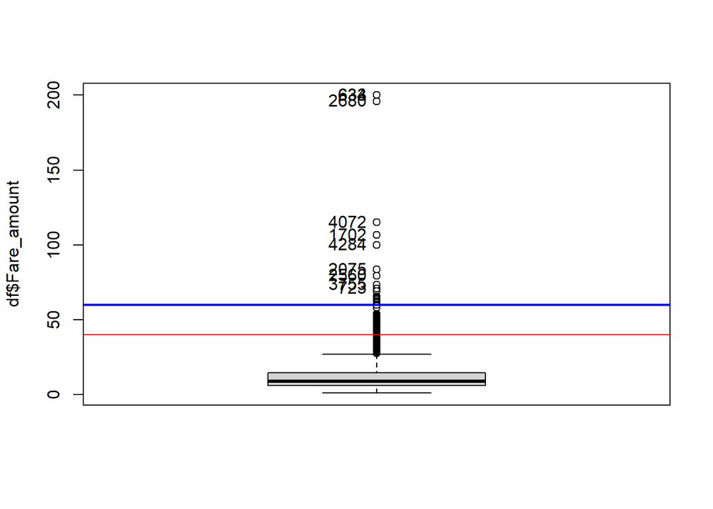

```r
var_out<-calcQ(df$Fare_amount)
abline(h=var_out$souts,col="red")
abline(h=var_out$souti,col="red")
abline(h=60,col="blue",lwd=2)
```

We decide to set outliers for fare amounts bigger than 60, because the majority of the values are concentrated between 0 and 60.

```r
llout<-which(df$Fare_amount>60)
iouts[llout]<-iouts[llout]+1
jouts[12]<-length(llout)
df[llout,"Fare_amount"]<-NA
# llout
```

### 14. Extra

As this variable is price related, it cannot have negative values, so this individuals will be treated as errors.

```r
summary(df$Extra)
```

```
##    Min. 1st Qu.  Median    Mean 3rd Qu.    Max.
## -1.0000  0.0000  0.5000  0.3517  0.5000  1.0000
```

We execute table in order to see every different value in the sample

```r
table(df$Extra)
```

```
##
##   -1 -0.5    0  0.5    1
##    2    5 2296 1868  829
```

As it is a price related variable, negative values should be treated as errors, and the other values are the ones defined for this variable, so there are not outliers.

```r
# df[which(df[, "Extra"] < 0),]
sel<-which(df$Extra < 0)
ierrs[sel]<-ierrs[sel]+1
# names(df)
jerrs[13]<-length(sel)
df[sel,"Extra"]<-NA
# sel
```

### 15. MTA_tax

This variable corresponds to a tax that must be charged in every trip and its cost is $0.50, so values different from this are errors, and we don’t have to take into account outliers because after the errors detection all values should be the MTA_tax.

```r
summary(df$MTA_tax)
```

```
##    Min. 1st Qu.  Median    Mean 3rd Qu.    Max.
## -0.5000  0.5000  0.5000  0.4857  0.5000  0.5000
```

```r
# df[which(df[, "MTA_tax"] != 0.50),]
```

**Important note:** We assume that when this tax is 0, it means there has been no payment. Therefore, we say that payment in these cases is equivalent to “no paid”.

```r
sel<-which(df$MTA_tax != 0.50)
ierrs[sel]<-ierrs[sel]+1
# names(df)
jerrs[14]<-length(sel)
df[sel,"MTA_tax"]<-NA
# sel
```

If we execute a summary, we’ll see that every value should be 0.5, so we proceed to categorize this variable.

```r
summary(df$MTA_tax)
```

```
##    Min. 1st Qu.  Median    Mean 3rd Qu.    Max.    NA's
##     0.5     0.5     0.5     0.5     0.5     0.5     133
```

```r
df$MTA_tax <- factor(df$MTA_tax)
```

### 16. Improvement_surcharge

This variable corresponds to a charge that must be charged in every trip and its cost is $0.30, so values different from this are errors, and we don’t have to take into account outliers because after the errors detection all values should be the Improvement surcharge.

```r
summary(df$improvement_surcharge)
```

```
##    Min. 1st Qu.  Median    Mean 3rd Qu.    Max.
## -0.3000  0.3000  0.3000  0.2914  0.3000  0.3000
```

```r
table(df$improvement_surcharge)
```

```
##
## -0.3    0  0.3
##   11  121 4868
```

We know that this surcharge was leived in 2015, so we need to check if the 0 values correspond to trips before this year. That is what we are going to do.

```r
df$yearGt2015[(df$lpep_pickup_datetime >= "2015-01-01 00:00:00") & (df$improvement_surcharge == 0.3)] = 1
df$yearGt2015[(df$lpep_pickup_datetime < "2015-01-01 00:00:00") | (df$improvement_surcharge != 0.3)] = 0

table(df$yearGt2015)
```

```
##
##    0    1
##  132 4868
```

We see that the 0 individuals are errors, so we proceed to set them has NA and categorize this variable.

```r
sel<-which(df$improvement_surcharge <= 0)
ierrs[sel]<-ierrs[sel]+1
# names(df)
jerrs[18]<-length(sel)
df[sel,"improvement_surcharge"]<-NA
# sel
df$improvement_surcharge <- factor(df$improvement_surcharge)
```

### 17. Ehail_fee

We don’t take this into account because every value of our sample is NA.

```r
summary(df$Ehail_fee)
```

```
##    Mode    NA's
## logical    5000
```

### 18. Tip_amount

As this is a price related variable, negative values should be considered as errors, and big tips should be considered as outliers. Also tip amounts bigger than 0 for individuals with payment_type = “Cash” should be considered as errors as well.

```r
summary(df$Tip_amount)
```

```
##    Min. 1st Qu.  Median    Mean 3rd Qu.    Max.
##   0.000   0.000   0.000   1.217   2.000  96.000
```

We proceed to check if the 0 values are related with payment_type = “Credit card” and the passenger did not tip.

```r
df$CashTips[(df$Tip_amount > 0) & (df$Payment_type == "Cash")] = 1
df$CashTips[(df$Payment_type == "Credit card")] = 0
table(df$CashTips)
```

```
##
##    0
## 2455
```

We see that we have correct data, so we proceed to the outlier detection.

#### Outlier detection

```r
Boxplot(df$Tip_amount)
```

```
##  [1] 4181  633  634 3295 4918 2194 1702   46 1433 2075
```

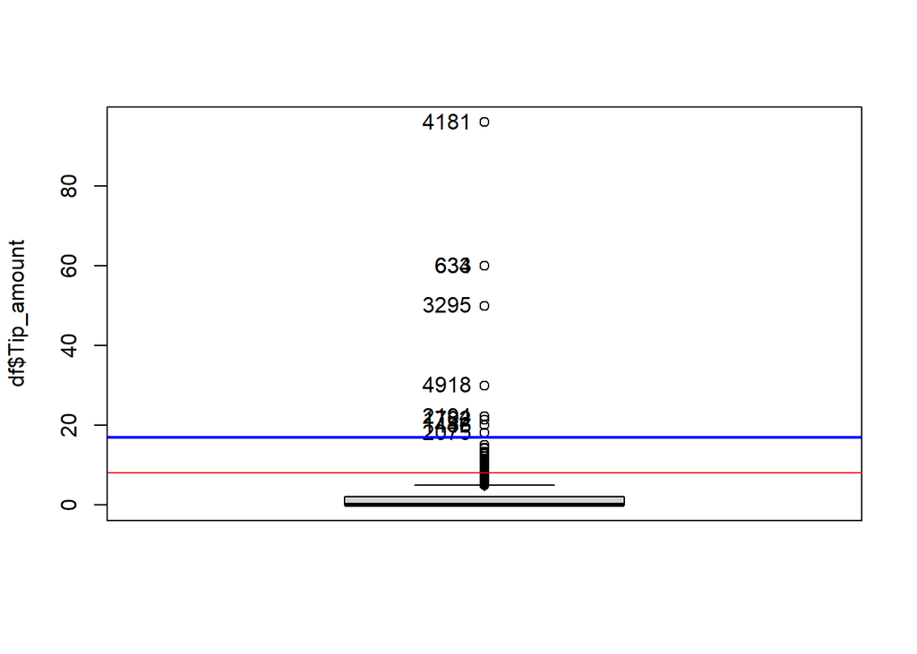

```r
var_out<-calcQ(df$Tip_amount)
abline(h=var_out$souts,col="red")
abline(h=var_out$souti,col="red")
abline(h=17,col="blue",lwd=2)
```

```r
llout<-which(df$Tip_amount>17)
iouts[llout]<-iouts[llout]+1
# names(df)
jouts[15]<-length(llout)
df[llout,"Tip_amount"]<-NA
# llout
```

### 19. Tolls_amount

As this is a price related variable, negative values should be considered as errors.

```r
summary(df$Tolls_amount)
```

```
##     Min.  1st Qu.   Median     Mean  3rd Qu.     Max.
##  0.00000  0.00000  0.00000  0.08369  0.00000 18.04000
```

We see that there are not negative values, so we do not have errors. We proceed now to the outlier detection.

```r
Boxplot(df$Tolls_amount)
```

```
##  [1] 2194 2560 3040 3289  415 2864 2474  122  347  379
```

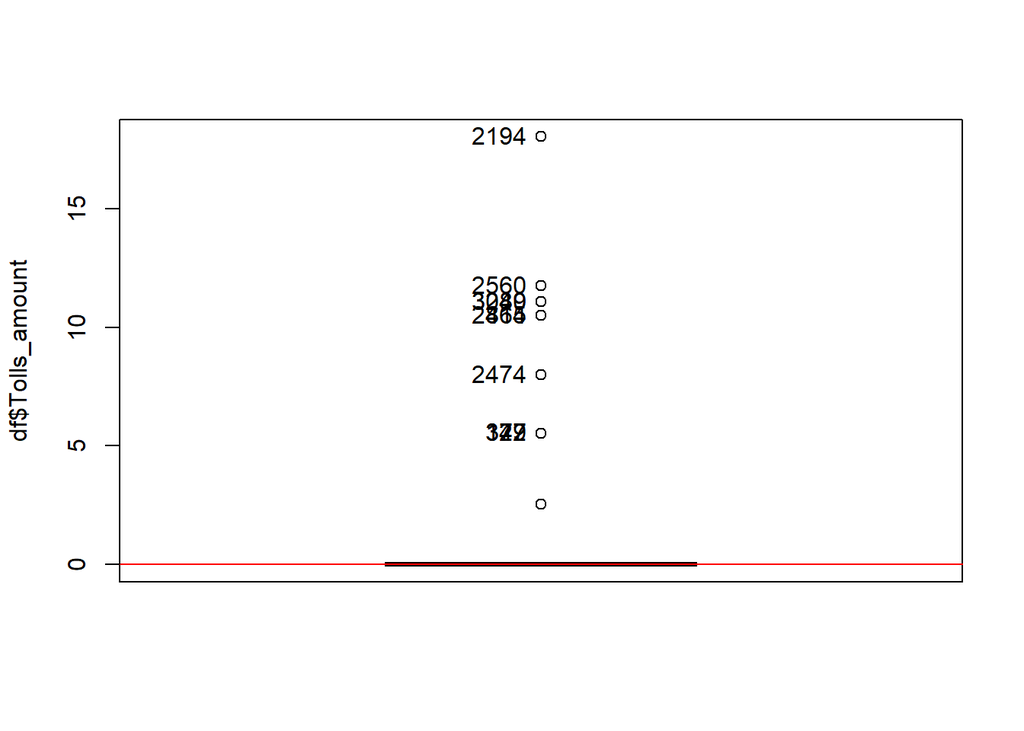

```r
var_out<-calcQ(df$Tolls_amount)
abline(h=var_out$souts,col="red")
abline(h=var_out$souti,col="red")
```

```r
table(df$Tolls_amount)
```

```
##
##     0  2.54  5.54     8  10.5 11.08 11.75 18.04
##  4931     2    60     1     2     2     1     1
```

As we see in the boxplot and the table, the majority of the individuals are 0, so the values bigger than 0 will be outliers. After having the outliers, we proceed to categorize this variable.

```r
llout<-which(df$Tolls_amount>0)
iouts[llout]<-iouts[llout]+1
# names(df)
jouts[16]<-length(llout)
df[llout,"Tolls_amount"]<-NA
# llout

df$Tolls_amount <- factor(df$Tolls_amount)
```

### 20. Total_amount

This is a price related variable, so negative values should be treated as errors. Also, we need to sum the “Fare_amount”, “Extra”,“MTA_tax”, “Improvement_surcharge”, “Tip_amount” and the “Tolls_amount” in order to see if the Total_amount matches with this sum.

```r
summary(df$Total_amount)
```

```
##    Min. 1st Qu.  Median    Mean 3rd Qu.    Max.
##  -52.80    7.80   11.16   14.33   17.16  260.00
```

Negative values seem to be errors - 0 Total_amount is possible when Payment_type ==“No charge”

We proceed to check if total amount is correctsumming the other variables and checking negatives values:

```r
df$Sum_total_amount = (df$Fare_amount + df$Extra + df$MTA_tax + df$improvement_surcharge + df$Tip_amount + df$Tolls_amount)
sel<-which((df$Total_amount != df$Sum_total_amount) | (df$Total_amount<0))
# names(df)
if (length(sel)>0) {
  ierrs[sel]<-ierrs[sel]+1
  jerrs[19]<-length(sel)
}
# sel
df[sel,"Total_amount"]<-NA
```

#### Outlier detection

```r
Boxplot(df$Total_amount)
```

```
##  [1]  633  634 2680 1702 4072 2194 2075 4181 4284 2560
```

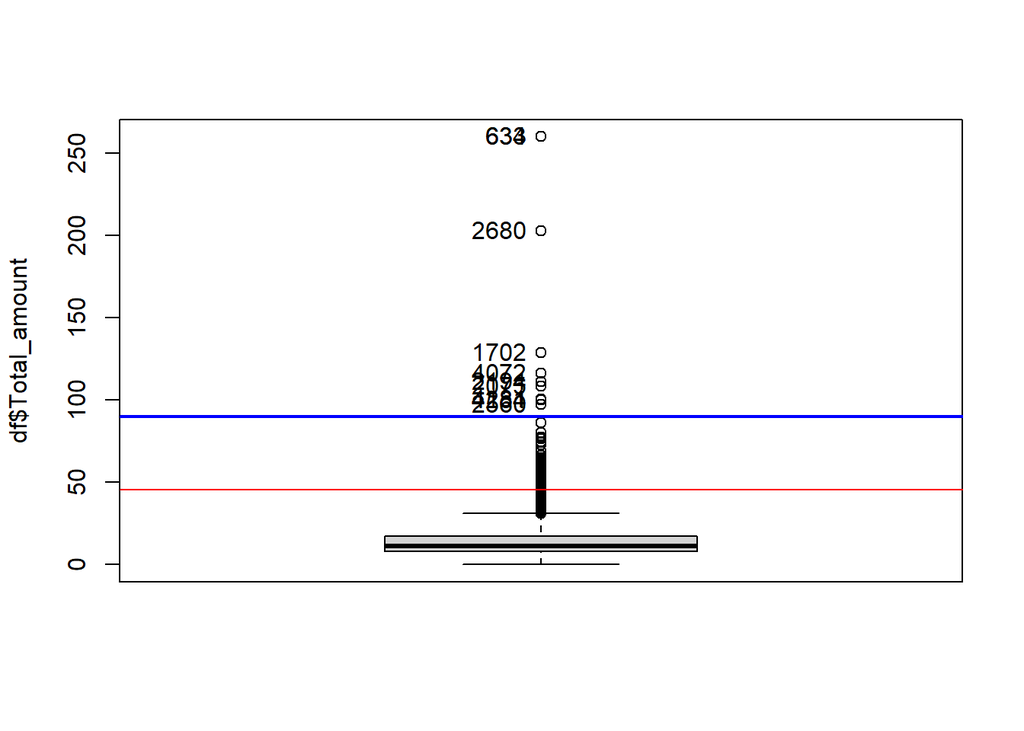

```r
var_out<-calcQ(df$Total_amount)
abline(h=var_out$souts,col="red")
abline(h=var_out$souti,col="red")
abline(h=90,col="blue",lwd=2)
```

```r
llout<-which(df$Total_amount>90)
iouts[llout]<-iouts[llout]+1
jouts[19]<-length(llout)
df[llout,"Total_amount"]<-NA
```

# Data Quality Report

## Per variable

Per each variable, we have to count the following:

- number of missing values
- number of errors (including inconsistencies)
- number of outliers
- rank variables according the sum of missing values (and errors).

### Number of missing values of each variable

```r
missings_ranking_sortlist <- sort.list(mis1$mis_col, decreasing = TRUE)
for (j in missings_ranking_sortlist) {
  print(paste(names(df)[j], " : ", mis1$mis_col$mis_x[j]))
}
```

```
## [1] "Ehail_fee  :  5000"
## [1] "VendorID  :  0"
## [1] "lpep_pickup_datetime  :  0"
## [1] "Lpep_dropoff_datetime  :  0"
## [1] "Store_and_fwd_flag  :  0"
## [1] "RateCodeID  :  0"
## [1] "Pickup_longitude  :  0"
## [1] "Pickup_latitude  :  0"
## [1] "Dropoff_longitude  :  0"
## [1] "Dropoff_latitude  :  0"
## [1] "Passenger_count  :  0"
## [1] "Trip_distance  :  0"
## [1] "Fare_amount  :  0"
## [1] "Extra  :  0"
## [1] "MTA_tax  :  0"
## [1] "Tip_amount  :  0"
## [1] "Tolls_amount  :  0"
## [1] "improvement_surcharge  :  0"
## [1] "Total_amount  :  0"
## [1] "Payment_type  :  0"
## [1] "Trip_type  :  0"
```

### Number of errors per each variable

```r
errors_ranking_sortlist <- sort.list(jerrs, decreasing = TRUE)
for (j in errors_ranking_sortlist) {
  if(!is.na(names(df)[j])) { print(paste(names(df)[j], " : ", jerrs[j])) }
}
```

```
## [1] "MTA_tax  :  133"
## [1] "improvement_surcharge  :  132"
## [1] "Trip_distance  :  66"
## [1] "espeed  :  64"
## [1] "Fare_amount  :  24"
## [1] "Total_amount  :  11"
## [1] "Dropoff_longitude  :  9"
## [1] "Extra  :  7"
## [1] "Pickup_longitude  :  3"
## [1] "Pickup_latitude  :  3"
## [1] "Passenger_count  :  2"
## [1] "VendorID  :  0"
## [1] "lpep_pickup_datetime  :  0"
## [1] "Lpep_dropoff_datetime  :  0"
## [1] "Store_and_fwd_flag  :  0"
```

[output cut: 19 more lines]

### Number of outliers per each variable

```r
errors_ranking_sortlist <- sort.list(jouts, decreasing = TRUE)
for (j in errors_ranking_sortlist) {
  if(!is.na(names(df)[j])) print(paste(names(df)[j], " : ", jouts[j]))
}
```

```
## [1] "Dropoff_latitude  :  116"
## [1] "Dropoff_longitude  :  113"
## [1] "Pickup_latitude  :  87"
## [1] "Tolls_amount  :  69"
## [1] "espeed  :  48"
## [1] "Fare_amount  :  20"
## [1] "Pickup_longitude  :  19"
## [1] "Tip_amount  :  10"
## [1] "Total_amount  :  10"
## [1] "Trip_distance  :  4"
## [1] "VendorID  :  0"
## [1] "lpep_pickup_datetime  :  0"
## [1] "Lpep_dropoff_datetime  :  0"
## [1] "Store_and_fwd_flag  :  0"
## [1] "RateCodeID  :  0"
```

[output cut: 19 more lines]

## Per individual

Per each individuals, we have to count the following:

### Number of missing values

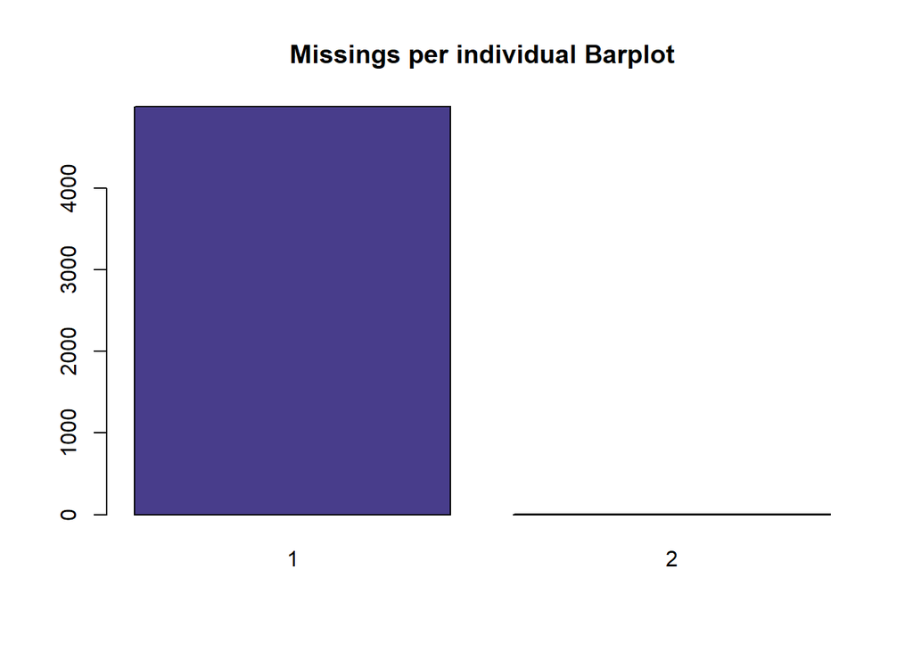

```r
# table(imis)
barplot(table(imis),main="Missings per individual Barplot",col = "DarkSlateBlue")
```

### Number of errors

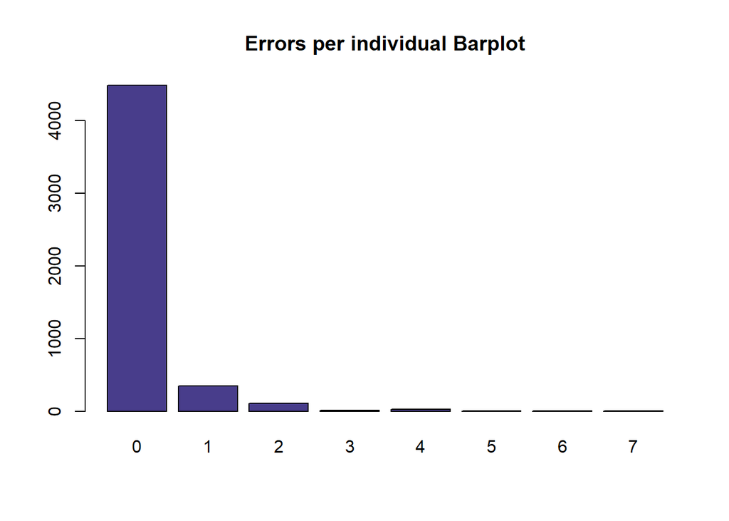

```r
# table(ierrs)
barplot(table(ierrs),main="Errors per individual Barplot",col = "DarkSlateBlue")
```

### Number of outliers

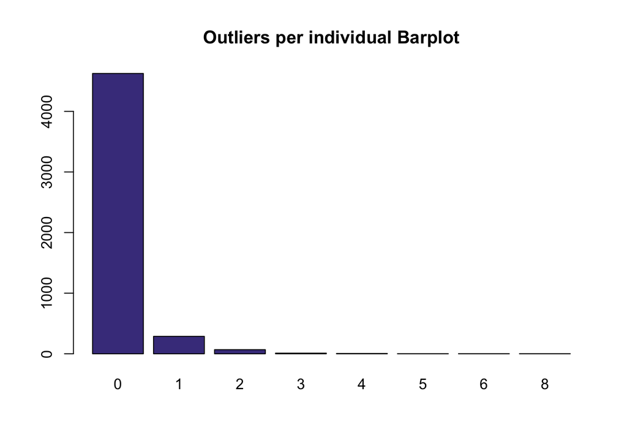

```r
# table(iouts)
barplot(table(iouts),main="Outliers per individual Barplot",col = "DarkSlateBlue")
```

## Create variable adding the total number missing values, outliers and errors

```r
total_missings <- 0; total_outliers <- 0; total_errors <- 0;
for (m in imis) {total_missings <- total_missings + m}
for (o in iouts) {total_outliers <- total_outliers + o}
for (e in ierrs) {total_errors <- total_errors + e}
```

Now, let’s print this variables:

```r
total_missings
```

```
## [1] 5000
```

```r
total_outliers
```

```
## [1] 496
```

```r
for (e in ierrs) {total_errors <- total_errors + e}; total_errors
```

```
## [1] 804
```

## Describe these variables, to which other variables exist higher associations

- compute the correlation with all other variables. Rank these variables according the correlation
- compute for every group of individuals (group of age, etc, …) the mean of missing/outliers/errors values. Rank the groups according the computed mean.

# Imputation

```r
library(missMDA)
```

## Numeric variables

We will now do the study by variables and try to impute the necessary observations.

```r
#vars_quantitatives<-names(df)[c(6:16, 18:19,27)]
vars_quantitatives<-names(df)[c(6:9, 11:13, 15, 19,27)]
# we do not include MTA_tax (14), Tolls_amount(16) nor improvement_surcharge(18)
summary(df[,vars_quantitatives])
```

```
##  Pickup_longitude Pickup_latitude Dropoff_longitude Dropoff_latitude
##  Min.   :-74.02   Min.   :40.58   Min.   :-74.02    Min.   :40.58
##  1st Qu.:-73.96   1st Qu.:40.70   1st Qu.:-73.97    1st Qu.:40.70
##  Median :-73.95   Median :40.75   Median :-73.94    Median :40.75
##  Mean   :-73.94   Mean   :40.75   Mean   :-73.94    Mean   :40.74
##  3rd Qu.:-73.92   3rd Qu.:40.80   3rd Qu.:-73.91    3rd Qu.:40.79
##  Max.   :-73.80   Max.   :40.86   Max.   :-73.80    Max.   :40.86
##  NA's   :22       NA's   :87      NA's   :122       NA's   :125
##  Trip_distance     Fare_amount        Extra          Tip_amount
##  Min.   : 0.010   Min.   : 1.00   Min.   :0.0000   Min.   : 0.00
##  1st Qu.: 1.050   1st Qu.: 6.00   1st Qu.:0.0000   1st Qu.: 0.00
##  Median : 1.810   Median : 9.00   Median :0.5000   Median : 0.00
##  Mean   : 2.770   Mean   :11.64   Mean   :0.3531   Mean   : 1.14
##  3rd Qu.: 3.458   3rd Qu.:14.50   3rd Qu.:0.5000   3rd Qu.: 2.00
##  Max.   :27.000   Max.   :60.00   Max.   :1.0000   Max.   :15.00
##  NA's   :70       NA's   :44      NA's   :7        NA's   :10
##   Total_amount       espeed
##  Min.   : 0.00   Min.   : 3.239
##  1st Qu.: 7.80   1st Qu.:14.885
##  Median :10.80   Median :18.689
##  Mean   :13.93   Mean   :20.596
##  3rd Qu.:17.16   3rd Qu.:23.759
##  Max.   :86.15   Max.   :77.249
##  NA's   :362     NA's   :114
```

```r
res.imputation<-imputePCA(df[,vars_quantitatives],ncp=5)
summary(res.imputation$completeObs)
```

```
##  Pickup_longitude Pickup_latitude Dropoff_longitude Dropoff_latitude
##  Min.   :-74.02   Min.   :40.58   Min.   :-74.02    Min.   :40.58
##  1st Qu.:-73.96   1st Qu.:40.70   1st Qu.:-73.97    1st Qu.:40.70
##  Median :-73.95   Median :40.75   Median :-73.94    Median :40.75
##  Mean   :-73.94   Mean   :40.75   Mean   :-73.94    Mean   :40.74
##  3rd Qu.:-73.92   3rd Qu.:40.80   3rd Qu.:-73.91    3rd Qu.:40.79
##  Max.   :-73.80   Max.   :40.86   Max.   :-73.80    Max.   :40.86
##  Trip_distance      Fare_amount        Extra          Tip_amount
##  Min.   :-0.3686   Min.   : 1.00   Min.   :0.0000   Min.   : 0.000
##  1st Qu.: 1.0400   1st Qu.: 6.00   1st Qu.:0.0000   1st Qu.: 0.000
##  Median : 1.8100   Median : 9.00   Median :0.5000   Median : 0.000
##  Mean   : 2.7747   Mean   :11.73   Mean   :0.3531   Mean   : 1.142
##  3rd Qu.: 3.4700   3rd Qu.:14.50   3rd Qu.:0.5000   3rd Qu.: 2.000
##  Max.   :27.0000   Max.   :75.98   Max.   :1.0000   Max.   :15.000
##   Total_amount       espeed
##  Min.   : 0.00   Min.   : 1.518
##  1st Qu.: 7.80   1st Qu.:14.905
##  Median :11.16   Median :18.706
##  Mean   :14.20   Mean   :20.650
##  3rd Qu.:17.30   3rd Qu.:23.786
##  Max.   :86.15   Max.   :77.249
```

We proceed to impute all NAs in our numerical variables that are stored in: `res.imputation$completeObs`

```r
# summary(res.imputation$completeObs)
df[,"Pickup_longitude"] <- res.imputation$completeObs[,"Pickup_longitude"]
df[,"Pickup_latitude"] <- res.imputation$completeObs[,"Pickup_latitude"]
df[,"Dropoff_longitude"] <- res.imputation$completeObs[,"Dropoff_longitude"]
df[,"Dropoff_latitude"] <- res.imputation$completeObs[,"Dropoff_latitude"]
df[,"Trip_distance"] <- res.imputation$completeObs[,"Trip_distance"]
df[,"Fare_amount"] <- res.imputation$completeObs[,"Fare_amount"]
df[,"Extra"] <- res.imputation$completeObs[,"Extra"]
df[,"Tip_amount"] <- res.imputation$completeObs[,"Tip_amount"]
df[,"Total_amount"] <- res.imputation$completeObs[,"Total_amount"]
df[,"espeed"] <- res.imputation$completeObs[,"espeed"]
```

## Categorical variables / Factors

## Result variables

```r
vars_restult<-names(df)[c(19,33)]
```

## Describe these variables, to which other variables exist higher associations * compute the correlation with all other variables. Rank these variables according the correlation * compute for every group of individuals (group of age, etc, …) the mean of missing/outliers/errors values. Rank the groups according the computed mean.

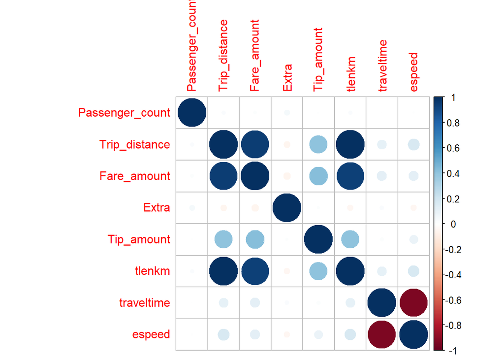

# !!!!!!! Passenger_count ha de ser categorica!!

```r
names(df)
```

```
##  [1] "VendorID"              "lpep_pickup_datetime"  "Lpep_dropoff_datetime"
##  [4] "Store_and_fwd_flag"    "RateCodeID"            "Pickup_longitude"
##  [7] "Pickup_latitude"       "Dropoff_longitude"     "Dropoff_latitude"
## [10] "Passenger_count"       "Trip_distance"         "Fare_amount"
## [13] "Extra"                 "MTA_tax"               "Tip_amount"
## [16] "Tolls_amount"          "Ehail_fee"             "improvement_surcharge"
## [19] "Total_amount"          "Payment_type"          "Trip_type"
## [22] "hour"                  "period"                "f.Rate"
## [25] "tlenkm"                "traveltime"            "espeed"
## [28] "pickup"                "dropoff"               "passenger_groups"
## [31] "Trip_distance_range"   "yearGt2015"            "CashTips"
## [34] "Sum_total_amount"
```

```r
vars_categorical<-names(df)[c(1,4,20,21, 23, 24, 30,31)] # Passenger_count_categorical!!! f.rate
# summary(df[,vars_categorical])
#
# vars_categorical<-names(df)[c(20:25)]
# nb <- estim_ncpMCA(df[, vars_categorical],ncp.max=25)
# # HOLA QUIERO MORIR NO FUNCIONA NADA
```

# Profiling

```r
# library(FactoMineR)
# summary(df[,vars_quantitatives])
```

```r
# library(mvoutlier)
# no puc seguir sense lo de dalt
# FUCK MY LIFE
```

- numeric Target (Total Amount)
- factor (Y.bin - Given Tip?)

### Identify individuals considered as multivariant outliers

```r
#library(chemometrics)
#multivariant_outliers <- Moutlier(df[, c(11:12, 19)], quantile = 0.995)

#!!!!! effective speed
#[1] ""              ""  "" ""
#[5] ""            ""      ""       ""
#[9] ""      ""       "Trip_distance"         "Fare_amount"
#[13] ""                 ""               "Tip_amount"            ""
#[17] ""             "" "Total_amount"          ""
#[21] ""             ""                ""                ""
#[25] ""   ""            ""              ""


# library(chemometrics)
# dis <- Moutlier(SwissLabor[,2:4], quantile = 0.995)
# dis$cutoff
# par(mfrow=c(1,1))
# plot(dis$md,dis$rd, type="n") text(dis$md,dis$rd,labels=rownames(SwissLabor[,2:4])) abline(h=qchisq(0.995, ncol(SwissLabor[,2:4])),col="red",lwd=2)
# SwissLabor$mout<-0
# sel<-which(dis$rd>12)
# SwissLabor[sel,"mout"]<-1
```